# xuz16 Notebook:

xuz16 Assignment 1 (Fall 2021)

Zhengwen Xu

09/02/2021

# 1 Introductory Decentralized Finance (DeFi) Research Notebook

This notebook is broken into two main parts:

```
* Part 1 is a basic introduction to github and RStudio Server
* Part 2 is an introduction to the DeFi transaction dataset
```

This R Notebook and its related R scripts provide a very basic introduction to an interesting **Decentralized Finance (DeFi)** dataset. All data was obtained by querying an API on [The Graph](https://thegraph.com/), an indexing protocol for querying networks like Ethereum, for transaction data based on [the AAVE protocol](https://thegraph.com/explorer/subgraph?id=0x0d69090672c1e5a94e9aedfbc59558d18a78e1d3-0&view=Overview). For more information on AAVE see [the AAVE developer notes](https://docs.aave.com/developers/v/2.0/). The AAVE protocol is based on [Ethereum](https://ethereum.org/en/), an important cryptocurrency platform.

The RPI github repository for all the code required for this notebook, including a snapshots of AAVE transaction and user data, may be found at:

- https://github.rpi.edu/DataINCITE/IDEA-Blockchain

The IDEA-Blockchain github also contains notebooks used to harvest the AAVE dataset, which you are welcome to examine.

## 1.1 BEFORE YOU BEGIN

To contribute or submit to any RPI github repository you must validate your RPI github.com ID and send a confirmation email to John Erickson at `erickj4@rpi.edu`. Please do the following **now**:

- Browse to http://github.rpi.edu
- Log in using your RPI credentials
- **PLEASE DO THIS IMMEDIATELY BEFORE READING ANY FURTHER!!**

## 1.2 DAR ASSIGNMENT 1: CLONING A NOTEBOOK AND UPDATING THE REPOSITORY

In this assignment we’re asking you to…

- clone the `IDEA-Blockchain` github repository…
- create a personal branch using git…
- copy and change an R notebook…
- generate (“knit”) a PDF based on that notebook, and…
- add these new files by “committing” and “pushing” to the github repository

*The instructions which follow explain how to accomplish this.*

**NOTE: For DAR Fall 2021** you *must* be using RStudio Server on the IDEA Cluster. Instructions for accessing “The Cluster” appear at the end of this notebook. Also, don’t forget to validate your RPI github ID as above and email `erickj4@rpi.edu`

### 1.2.1 Cloning an RPI github repository

The recommended procedure for cloning and using this repository is as follows:

- Access the RPI network via VPN
  - See https://itssc.rpi.edu/hc/en-us/articles/360008783172-VPN-Connection-and-Installation for information
- Access RStudio Server on the IDEA Cluster at http://lp01.idea.rpi.edu/rstudio-ose/
  - You must be on the RPI VPN!!
- Access the Linux shell on the IDEA Cluster by clicking the **Terminal** tab of RStudio Server (lower left panel).
  - You now see the Linux shell on the IDEA Cluster
  - `cd` (change directory) to enter your home directory using: `cd ~`
  - Type `pwd` to confirm
  - NOTE: Advanced users may use `ssh` to directly access the Linux shell from a macOS or Linux command line
- Type `git clone https://github.rpi.edu/DataINCITE/IDEA-Blockchain.git` from within your `home` directory
  - This will create a new directory `IDEA-Blockchain`
- In the Linux shell, `cd` to `IDEA-Blockchain/DefiResearch/StudentNotebooks`
  - Type `ls -al` to list the current contents
  - Don’t be surprised if you see many files!
- In the Linux shell, type `git checkout -b dar-yourrcs` where `yourrcs` is your RCS id
  - For example, if your RCS is `erickj4`, your new branch should be `dar-erickj4`
  - It is *critical* that you include your RCS id in your branch id
- Now in the RStudio Server UI, navigate to the `IDEA-Blockchain/DefiResearch/StudentNotebooks` directory via the **Files** panel (lower right panel)
  - Under the **More** menu, set this to be your R **working directory**
  - *Setting the correct working directory is essential for interactive R use!*

### 1.2.2 REQUIRED FOR ASSIGMENT 1

Please also see this handy github “cheatsheet”: https://education.github.com/git-cheat-sheet-education.pdf

# 2 Exploring a DeFi Transaction Dataset using AAVE

*This section is provided as background and is not required for Assignment 1.*

## 2.1 What is AAVE?

From the [developer site](https://docs.aave.com/developers/v/2.0/): *Aave is a decentralised non-custodial liquidity protocol where users can participate as depositors or borrowers. Depositors provide liquidity to the market to earn a passive income, while borrowers are able to borrow in an over-collateralised (perpetually) or under-collateralised (one-block liquidity) fashion…The (Aave) protocol is implemented as a set of smart contracts on top of the [Ethereum](https://ethereum.org/en/) blockchain. Smart contracts guarantee safety and do not require a middleman.*

For (much) more detail refer to the [AAVE Protocol V2.0 Whitepaper](https://github.com/aave/protocol-v2/blob/master/aave-v2-whitepaper.pdf)

## 2.2 Prepare Transaction Data

We are directly loading the dataframe from an Rds archive instead of a CSV file to conserve space.

```r
#load Rds (binary version of csv file) into dataframe
df<-read_rds('../Data/transactions.Rds')

# Let's take a quick look
head(df)
```

|  | amount | borrowRate | borrowRateMode | onBehalfOf | pool | reserve | timestamp | user | type | reservePriceETH | reservePriceUSD | amountUSD | collateralAmount | collateralReserve | principalAmount | principalReserve | reservePriceETHPrincipal | reservePriceUSDPrincipal | reservePriceETHCollateral | reservePriceUSDCollateral | amountUSDPincipal | amountUSDCollateral | borrowRateModeFrom | borrowRateModeTo | stableBorrowRate | variableBorrowRate |
| --- | --- | --- | --- | --- | --- | --- | --- | --- | --- | --- | --- | --- | --- | --- | --- | --- | --- | --- | --- | --- | --- | --- | --- | --- | --- | --- |
| 1 | 41501.63 | 6.274937 | Variable | 8.502518e+47 | 1.034668e+48 | DAI | 1621340435 | 8.502518e+47 | borrow | 2.852900e+14 | 0.9948044 | 41286.00 | NA |  | NA |  | NA | NA | NA | NA | NA | NA |  |  | NA | NA |
| 2 | 7000000.00 | 2.589628 | Variable | 4.635974e+47 | 1.034668e+48 | USDT | 1622477822 | 4.635974e+47 | borrow | 3.812835e+14 | 1.0000000 | 7000000.00 | NA |  | NA |  | NA | NA | NA | NA | NA | NA |  |  | NA | NA |
| 3 | 15000.00 | 8.802541 | Variable | 3.735263e+47 | 1.034668e+48 | USDC | 1619775984 | 3.735263e+47 | borrow | 3.611000e+14 | 1.0043389 | 15065.08 | NA |  | NA |  | NA | NA | NA | NA | NA | NA |  |  | NA | NA |
| 4 | 8193.19 | 48.747052 | Stable | 6.896232e+47 | 1.034668e+48 | USDC | 1615481632 | 6.896232e+47 | borrow | 5.562201e+14 | 0.9993909 | 8188.20 | NA |  | NA |  | NA | NA | NA | NA | NA | NA |  |  | NA | NA |
| 5 | 11000.00 | 3.225055 | Variable | 1.089455e+48 | 1.034668e+48 | USDT | 1626914745 | 1.089455e+48 | borrow | 4.971100e+14 | 1.0000000 | 11000.00 | NA |  | NA |  | NA | NA | NA | NA | NA | NA |  |  | NA | NA |
| 6 | 40000.00 | 5.739208 | Variable | 2.178337e+47 | 1.034668e+48 | USDT | 1620936688 | 2.178337e+47 | borrow | 2.725248e+14 | 1.0000000 | 40000.00 | NA |  | NA |  | NA | NA | NA | NA | NA | NA |  |  | NA | NA |

```r
str(df)
```

```
## 'data.frame':    481519 obs. of  26 variables:
##  $ amount                   : num  41502 7000000 15000 8193 11000 ...
##  $ borrowRate               : num  6.27 2.59 8.8 48.75 3.23 ...
##  $ borrowRateMode           : Factor w/ 3 levels "","Stable","Variable": 3 3 3 2 3 3 3 3 3 2 ...
##  $ onBehalfOf               : num  8.50e+47 4.64e+47 3.74e+47 6.90e+47 1.09e+48 ...
##  $ pool                     : num  1.03e+48 1.03e+48 1.03e+48 1.03e+48 1.03e+48 ...
##  $ reserve                  : Factor w/ 50 levels "","AAVE","AmmBptBALWETH",..: 29 45 44 44 45 45 44 44 47 44 ...
##  $ timestamp                : int  1621340435 1622477822 1619775984 1615481632 1626914745 1620936688 1628036958 1627829736 1622219455 1624622688 ...
##  $ user                     : num  8.50e+47 4.64e+47 3.74e+47 6.90e+47 1.09e+48 ...
##  $ type                     : Factor w/ 6 levels "borrow","deposit",..: 1 1 1 1 1 1 1 1 1 1 ...
##  $ reservePriceETH          : num  2.85e+14 3.81e+14 3.61e+14 5.56e+14 4.97e+14 ...
##  $ reservePriceUSD          : num  0.995 1 1.004 0.999 1 ...
##  $ amountUSD                : num  41286 7000000 15065 8188 11000 ...
##  $ collateralAmount         : num  NA NA NA NA NA NA NA NA NA NA ...
##  $ collateralReserve        : Factor w/ 25 levels "","AAVE","AmmBptBALWETH",..: 1 1 1 1 1 1 1 1 1 1 ...
##  $ principalAmount          : num  NA NA NA NA NA NA NA NA NA NA ...
##  $ principalReserve         : Factor w/ 27 levels "","AmmDAI","AmmUSDC",..: 1 1 1 1 1 1 1 1 1 1 ...
##  $ reservePriceETHPrincipal : num  NA NA NA NA NA NA NA NA NA NA ...
##  $ reservePriceUSDPrincipal : num  NA NA NA NA NA NA NA NA NA NA ...
##  $ reservePriceETHCollateral: num  NA NA NA NA NA NA NA NA NA NA ...
##  $ reservePriceUSDCollateral: num  NA NA NA NA NA NA NA NA NA NA ...
##  $ amountUSDPincipal        : num  NA NA NA NA NA NA NA NA NA NA ...
##  $ amountUSDCollateral      : num  NA NA NA NA NA NA NA NA NA NA ...
##  $ borrowRateModeFrom       : Factor w/ 3 levels "","Stable","Variable": 1 1 1 1 1 1 1 1 1 1 ...
##  $ borrowRateModeTo         : Factor w/ 3 levels "","Stable","Variable": 1 1 1 1 1 1 1 1 1 1 ...
##  $ stableBorrowRate         : num  NA NA NA NA NA NA NA NA NA NA ...
##  $ variableBorrowRate       : num  NA NA NA NA NA NA NA NA NA NA ...
```

```r
summary(df)
```

```
##      amount            borrowRate       borrowRateMode     onBehalfOf
##  Min.   :        0   Min.   :    0.0           :386542   Min.   :2.578e+33
##  1st Qu.:       24   1st Qu.:    3.3   Stable  : 18408   1st Qu.:4.174e+47
##  Median :     1427   Median :    3.9   Variable: 76569   Median :7.522e+47
##  Mean   :   191103   Mean   :    9.5                     Mean   :7.592e+47
##  3rd Qu.:    24382   3rd Qu.:   10.8                     3rd Qu.:1.168e+48
##  Max.   :600000000   Max.   :10002.0                     Max.   :1.461e+48
##  NA's   :7289        NA's   :386542                      NA's   :7289
##       pool              reserve         timestamp              user
##  Min.   :9.862e+47   USDC   :105937   Min.   :1.607e+09   Min.   :2.578e+33
##  1st Qu.:1.035e+48   WETH   :105279   1st Qu.:1.615e+09   1st Qu.:4.199e+47
##  Median :1.035e+48   USDT   : 58266   Median :1.621e+09   Median :8.697e+47
##  Mean   :1.034e+48   DAI    : 55211   Mean   :1.620e+09   Mean   :8.082e+47
##  3rd Qu.:1.035e+48   LINK   : 26404   3rd Qu.:1.624e+09   3rd Qu.:1.173e+48
##  Max.   :1.035e+48   WBTC   : 26344   Max.   :1.629e+09   Max.   :1.461e+48
##                      (Other):104078
##           type        reservePriceETH     reservePriceUSD
##  borrow     : 94977   Min.   :1.000e+00   Min.   :0.000e+00
##  deposit    :192006   1st Qu.:2.865e+14   1st Qu.:1.000e+00
##  liquidation:  6289   Median :4.652e+14   Median :1.000e+00
##  redeem     :126705   Mean   :3.458e+23   Mean   :6.774e+08
##  repay      : 60542   3rd Qu.:9.411e+14   3rd Qu.:1.000e+00
##  swap       :  1000   Max.   :1.647e+28   Max.   :4.252e+13
##                       NA's   :7289        NA's   :7289
##    amountUSD         collateralAmount  collateralReserve principalAmount
##  Min.   :        0   Min.   :      0          :475230    Min.   :      0
##  1st Qu.:       70   1st Qu.:      1   WETH   :  2665    1st Qu.:    962
##  Median :     5836   Median :     14   LINK   :  1312    Median :   4362
##  Mean   :   245851   Mean   :   5451   WBTC   :   686    Mean   :  66005
##  3rd Qu.:    49871   3rd Qu.:    250   AAVE   :   333    3rd Qu.:  21533
##  Max.   :754379487   Max.   :4638724   UNI    :   230    Max.   :4475668
##  NA's   :7289        NA's   :475230    (Other):  1063    NA's   :475230
##  principalReserve reservePriceETHPrincipal reservePriceUSDPrincipal
##         :475230   Min.   :1.000e+00        Min.   :    0.0
##  USDC   :  2142   1st Qu.:4.062e+14        1st Qu.:    1.0
##  USDT   :  1549   Median :4.682e+14        Median :    1.0
##  DAI    :  1459   Mean   :1.556e+17        Mean   :  295.6
##  GUSD   :   242   3rd Qu.:5.363e+14        3rd Qu.:    1.0
##  TUSD   :   175   Max.   :4.203e+19        Max.   :83819.1
##  (Other):   722   NA's   :475230           NA's   :475230
```

[output cut: 9 more lines]

```
##  Min.   :      0             :480519            :480519   Min.   :  0.0
##  1st Qu.:      0     Stable  :   471    Stable  :   529   1st Qu.:  9.0
##  Median :    476     Variable:   529    Variable:   471   Median : 10.9
##  Mean   :  37060                                          Mean   : 11.7
##  3rd Qu.:   7457                                          3rd Qu.: 12.0
##  Max.   :5029023                                          Max.   :154.7
##  NA's   :475230                                           NA's   :480519
##  variableBorrowRate
##  Min.   :  0.0
##  1st Qu.:  3.8
##  Median :  3.9
##  Mean   :  5.7
##  3rd Qu.:  5.1
##  Max.   :148.7
##  NA's   :480519
```

## 2.3 Analyze Transaction Types

Next, we will examine the different types of transactions present in the data. We make a bar plot to visualize the number of each transaction types. Deposit is the most common type of transaction, whereas swaps are the most rare.

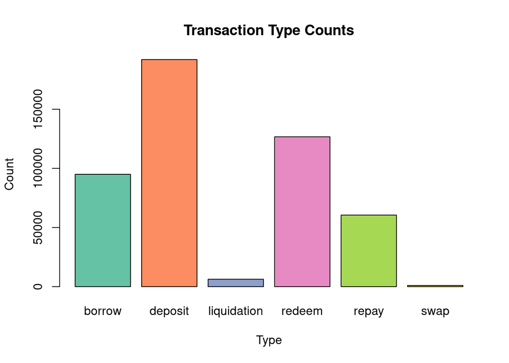

```r
#set color palette
colors = brewer.pal(6,"Set2")

#create barplot
barplot(table(df$type), main='Transaction Type Counts', xlab='Type',ylab='Count',col=colors)
```

There are more deposits than borrows, because users often need to overcollateralize for loans.

Now, we will examine the amount of US dollars being used in the different types of transactions. We create box plots for the 4 types of transactions that have the amount feature associated with them, and visualize the distribution of that column for the different transactions. We can see that most transactions are completed with very little money.

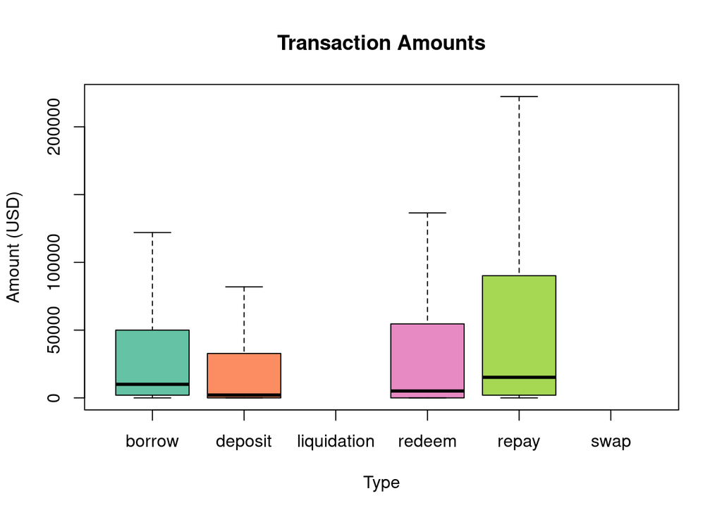

```r
#create boxplot
boxplot(amountUSD~type,data=df,outline=FALSE,col=colors,main="Transaction Amounts",xlab="Type",ylab="Amount (USD)")
```

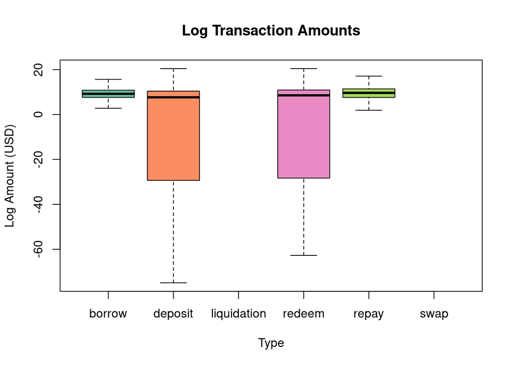

```r
boxplot(log(amountUSD)~type,data=df,outline=FALSE,col=colors,main="Log Transaction Amounts",xlab="Type",ylab="Log Amount (USD)")
```

## 2.4 Look at Sample User Transaction Histories

Finally, we will examine the transaction history of different users. To do this, we will select 3 random users from the data who have completed between 100 and 300 transactions. Then, we create swarmplots displaying the different types of transactions those users made over time.

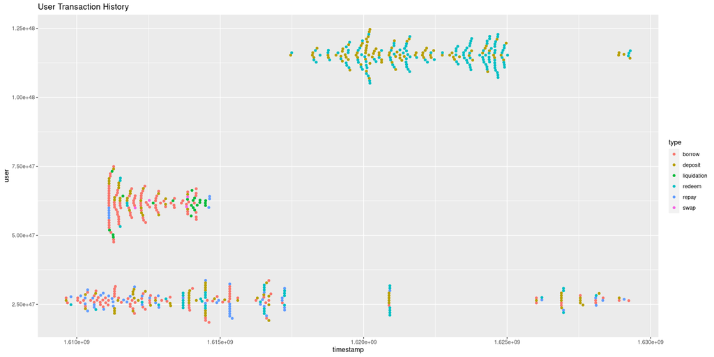

```r
#set seed
set.seed(1)

#get 3 random users that have between 100 and 300 transactions
users<-vector(length=3)
count<-0
while(count<=3){
  success<-FALSE
  while(!success){
    #get random user
    ruser<-sample(df$user,1)

    #check for valid number of transactions
    length<-nrow(filter(df,user==ruser))
    if (length>100 && length<300){
      users[count]=ruser
      success<-TRUE
      count<-count+1
    }
  }
}
df.rusers<-filter(df, user %in%users)

#create swarmplot

#liquidations
#borrow
#deposit
#redeem
#repay
#swap

ggplot(df.rusers,aes(user, timestamp,color=type)) +
        geom_beeswarm(cex=1)+
        coord_flip()+
        ggtitle("User Transaction History")
```

Users have very different transactions patterns, which we will try to better understand.

## 2.5 Analyze Individual Currencies (USDT)

USDT is interesting because it has more borrows than deposits. This may be because it is a stable coin.

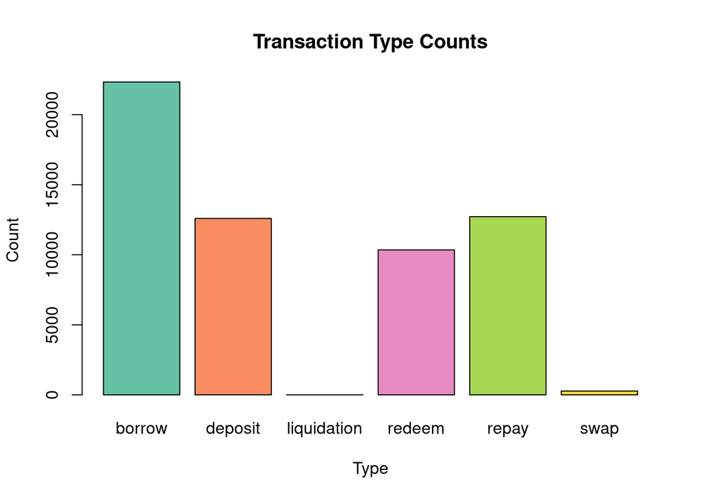

```r
df.usd<-filter(df,reserve=="USDT")
barplot(table(df.usd$type), main='Transaction Type Counts', xlab='Type',ylab='Count',col=colors)
```

# 3 APPENDIX: Accessing RStudio Server on the IDEA Cluster

The IDEA Cluster provides five compute nodes (4x 48 cores, 1x 80 cores, 1x storage server)

- The Cluster requires RCS credentials, enabled via registration in class
  - email John Erickson for problems `erickj4@rpi.edu`
- RStudio, Jupyter, MATLAB, GPUs (on two nodes); lots of storage and computes
- Access via RPI physical network or VPN only

**RStudio GUI Access for DAR:**

- Access the RPI VPN
- Browse to: http://lp01.idea.rpi.edu/rstudio-ose/ (RStudio Server)
- Log in using your RCS username and password
  - If you cannot log in, contact John Erickson at erickj4@rpi.edu

**Shared Data on Cluster:**

- Users enrolled in DAR have access to `/academics/MATP-4910-F21`
  - Usually DAR users will see a symbolic (“soft”) link in their home directories
  - If you do not, type the following in the **Terminal** via RStudio: `ln -s /academics/MATP-4910-F21/ MATP-4910-F21`

**For advanced users:**

- All idea_users have access to shared storage via `/data` (“data” in your home directories)
  - You might wish to use this for data sharing in team projects…
  - …but we recommend using github for shared code development
- Shell access to nodes: You must access “landing pad” first, then compute node:
- `ssh your_rcs@lp01.idea.rpi.edu` For example: `ssh erickj4@lp01.idea.rpi.edu`
- Then, `ssh` to the desired compute node, e.g.: `ssh idea-node-02`